# Alessandro Ossola

Associate Professor, University of California Davis

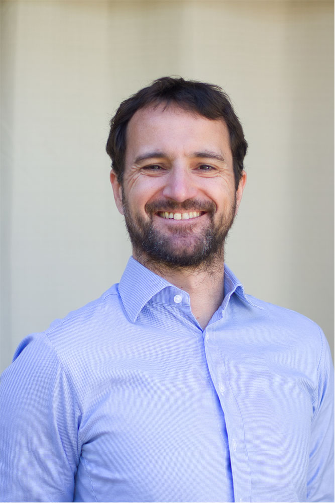

Dr. Alessandro Ossola is an Associate Professor in urban plant science at the University of California Davis. He is also a Honorary Research Fellow at the University of Melbourne, Australia, and a former US National Academy of Sciences, Engineering and Medicine NRC Associate with US-EPA in Cincinnati, OH. He is a recipient of a New Innovator Award from the Foundation for Food and Agriculture Research (FFAR). He is the inventor of the Global Urban Tree Inventory (GUTI) - the first database of the 5,000 tree species living in the world’s cities and a founding member of the Urban Tree Ecophysiology Network (UTEN).

Dr. Ossola’s research encompasses urban forestry, urban ecology, big data ecology and urban planning. Over the years, he lectured undergraduate and postgraduate subjects related to urban forestry, green infrastructures, nature-based solutions, urban biodiversity conservation, urban horticulture, eco-hydrology and landscape architecture. Alessandro is particularly interested in the applied side of his research, science communication and co-production.

Dr. Ossola is the Chair of the Saratoga Horticultural Research Endowment (SHRE) and Member of the Executive Oversight Team of the Los Angeles Center for Urban Natural Resources Sustainability. He advises many local, state, regional and federal government agencies on issues and policies related to urban land management, strategic planning and holistic governance.